# Scraping Data II

STAT 230

3/7/2017

## Movie Data Recap

Pre-requisite packages:

```r
library(XML)
library(omdbapi)
```

If the above packages don’t load, you will need to install the following packages:

```r
install.packages("XML")
install.packages("devtools")
devtools::install_github("hrbrmstr/omdbapi")
```

### Part 1

```r
imdb <- readHTMLTable("http://www.imdb.com/chart/top",
                       stringsAsFactors = FALSE)

# to access the second element of this list, say,
imdb[[2]]
```

```
##                                    V1
## 1 Amazon VideoWatch Movies &TV Online
##                                             V2
## 1 Prime VideoUnlimited Streamingof Movies & TV
##                                         V3
## 1 Amazon GermanyBuy Movies onDVD & Blu-ray
##                                       V4
## 1 Amazon ItalyBuy Movies onDVD & Blu-ray
##                                        V5
## 1 Amazon FranceBuy Movies onDVD & Blu-ray
##                                      V6                         V7
## 1 Amazon IndiaBuy Movie andTV Show DVDs DPReviewDigitalPhotography
##                           V8
## 1 AudibleDownloadAudio Books
```

```r
imdb <- imdb[[1]]
head(imdb)
```

```
##                                          Rank & Title IMDb Rating
## 1  1.\n      The Shawshank Redemption\n        (1994)         9.2
## 2             2.\n      The Godfather\n        (1972)         9.2
## 3    3.\n      The Godfather: Part II\n        (1974)         9.0
## 4           4.\n      The Dark Knight\n        (2008)         8.9
## 5              5.\n      12 Angry Men\n        (1957)         8.9
## 6          6.\n      Schindler's List\n        (1993)         8.9
##                                                                                                                  Your Rating
## 1 12345678910\n        \n        \n            \n            NOT YET RELEASED\n             \n            \n            Seen
## 2 12345678910\n        \n        \n            \n            NOT YET RELEASED\n             \n            \n            Seen
## 3 12345678910\n        \n        \n            \n            NOT YET RELEASED\n             \n            \n            Seen
## 4 12345678910\n        \n        \n            \n            NOT YET RELEASED\n             \n            \n            Seen
## 5 12345678910\n        \n        \n            \n            NOT YET RELEASED\n             \n            \n            Seen
## 6 12345678910\n        \n        \n            \n            NOT YET RELEASED\n             \n            \n            Seen
##
## 1
## 2
## 3
## 4
## 5
## 6
```

```r
colnames(imdb)
```

```
## [1] ""             "Rank & Title" "IMDb Rating"  "Your Rating"
## [5] ""
```

```r
imdb <- imdb[,2:3] # only really need the 2nd and 3rd columns
head(imdb)
```

```
##                                         Rank & Title IMDb Rating
## 1 1.\n      The Shawshank Redemption\n        (1994)         9.2
## 2            2.\n      The Godfather\n        (1972)         9.2
## 3   3.\n      The Godfather: Part II\n        (1974)         9.0
## 4          4.\n      The Dark Knight\n        (2008)         8.9
## 5             5.\n      12 Angry Men\n        (1957)         8.9
## 6         6.\n      Schindler's List\n        (1993)         8.9
```

Data scraped from the web will typically have some degree of messiness that needs to be cleaned. In this case, we can see that the first column of the dataset is informative, but is a bit too heterogeneous for us to work with. We’ll now take a sequence of steps to parse this out into a `title` column and a `year` column.

#### A quick reminder of functions for text processing:

- `grep()` - search for a text pattern and return indices of matches

```r
grep("abc", c("tabc", "abcd", "dcab"))
```

```
## [1] 1 2
```

- `substr()` - extract bits of text based on starting and ending locations

```r
# nchar(c("tabc", "abcd", "dcab"))
substr(c("tabc", "abcd", "dcab"), 2, 4)
```

```
## [1] "abc" "bcd" "cab"
```

- `gsub()` - search for a text pattern and replace it with another text pattern

```r
gsub(" ", ",", c("a bc", "d p lo"))
```

```
## [1] "a,bc"   "d,p,lo"
```

(This can also be used to extract elements of a string using regular expressions. See movie year example below.)

- `trimws()` - trim away trailing and leading whitespaces

```r
trimws(c("  abc", "a  bc"))
```

```
## [1] "abc"   "a  bc"
```

- `strsplit()` - split a string based on some text pattern

```r
a <- strsplit(c("a bc", "d p lo"), " ")
a[[1]]
```

```
## [1] "a"  "bc"
```

```r
a[[2]]
```

```
## [1] "d"  "p"  "lo"
```

```r
a[[2]][3]
```

```
## [1] "lo"
```

```r
title_years <- strsplit(imdb[,1], "\n")
head(title_years)
```

```
## [[1]]
## [1] "1."                             "      The Shawshank Redemption"
## [3] "        (1994)"
##
## [[2]]
## [1] "2."                  "      The Godfather" "        (1972)"
##
## [[3]]
## [1] "3."                           "      The Godfather: Part II"
## [3] "        (1974)"
##
## [[4]]
## [1] "4."                    "      The Dark Knight" "        (2008)"
##
## [[5]]
## [1] "5."                 "      12 Angry Men" "        (1957)"
##
## [[6]]
## [1] "6."                     "      Schindler's List"
## [3] "        (1993)"
```

```r
class(title_years)
```

```
## [1] "list"
```

```r
title_years <- unlist(title_years)
head(title_years)
```

```
## [1] "1."                             "      The Shawshank Redemption"
## [3] "        (1994)"                 "2."
## [5] "      The Godfather"            "        (1972)"
```

```r
class(title_years)
```

```
## [1] "character"
```

```r
imdb$year <- title_years[seq(3, length(title_years), 3)]
head(imdb$year)
```

```
## [1] "        (1994)" "        (1972)" "        (1974)" "        (2008)"
## [5] "        (1957)" "        (1993)"
```

```r
imdb$title <- title_years[seq(2, length(title_years), 3)]
head(imdb)
```

```
##                                         Rank & Title IMDb Rating
## 1 1.\n      The Shawshank Redemption\n        (1994)         9.2
## 2            2.\n      The Godfather\n        (1972)         9.2
## 3   3.\n      The Godfather: Part II\n        (1974)         9.0
## 4          4.\n      The Dark Knight\n        (2008)         8.9
## 5             5.\n      12 Angry Men\n        (1957)         8.9
## 6         6.\n      Schindler's List\n        (1993)         8.9
##             year                          title
## 1         (1994)       The Shawshank Redemption
## 2         (1972)                  The Godfather
## 3         (1974)         The Godfather: Part II
## 4         (2008)                The Dark Knight
## 5         (1957)                   12 Angry Men
## 6         (1993)               Schindler's List
```

```r
# imdb$year <- trimws(imdb$year)
# imdb$year <- substr(imdb$year, 2, 5)
# imdb$year <- as.numeric(imdb$year)

### another approach, using `gsub()`

tmp <- imdb$year[1]
tmp
```

```
## [1] "        (1994)"
```

```r
gsub(".*([[:digit:]]{4}).*", "\\1", tmp)
```

```
## [1] "1994"
```

```r
imdb$year <- as.numeric(gsub(".*([[:digit:]]{4}).*", "\\1", imdb$year))

head(imdb$year)
```

```
## [1] 1994 1972 1974 2008 1957 1993
```

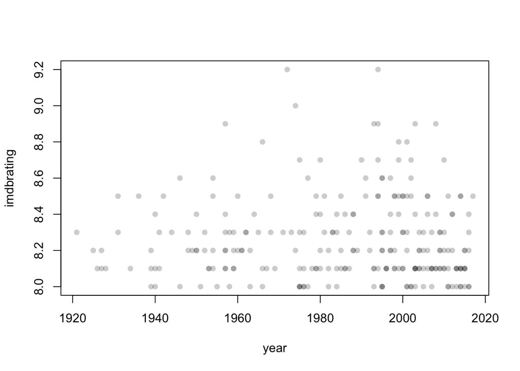

```r
###

imdb$title <- trimws(imdb$title)
imdb <- imdb[,-1]
imdb$rank <- 1:250

colnames(imdb)[1] <- "imdbrating"

plot(imdbrating ~ year, data=imdb, col=rgb(0, 0, 0, 0.2), pch=16)
```

### Part 2: using the API

```r
library(omdbapi)

movie <- find_by_title(imdb$title[2], year_of_release = imdb$year[2],
              include_tomatoes = TRUE)
names(movie)
```

```
##  [1] "Title"             "Year"              "Rated"
##  [4] "Released"          "Runtime"           "Genre"
##  [7] "Director"          "Writer"            "Actors"
## [10] "Plot"              "Language"          "Country"
## [13] "Awards"            "Poster"            "Metascore"
## [16] "imdbRating"        "imdbVotes"         "imdbID"
## [19] "Type"              "tomatoMeter"       "tomatoImage"
## [22] "tomatoRating"      "tomatoReviews"     "tomatoFresh"
## [25] "tomatoRotten"      "tomatoConsensus"   "tomatoUserMeter"
## [28] "tomatoUserRating"  "tomatoUserReviews" "tomatoURL"
## [31] "DVD"               "BoxOffice"         "Production"
## [34] "Website"           "Response"
```

```r
movie
```

```
##             Title: The Godfather
##              Year: 1972
##             Rated: R
##          Released: 1972-03-24
##           Runtime: 175 min
##             Genre: Crime, Drama
##          Director: Francis Ford Coppola
##            Writer: Mario Puzo (screenplay), Francis Ford Coppola (screenplay), Mario
##                    Puzo (novel)
##            Actors: Marlon Brando, Al Pacino, James Caan, Richard S. Castellano
##              Plot: The aging patriarch of an organized crime dynasty transfers
##                    control of his clandestine empire to his reluctant son.
##          Language: English, Italian, Latin
##           Country: USA
##            Awards: Won 3 Oscars. Another 23 wins & 27 nominations.
##            Poster: https://images-na.ssl-images-amazon.com/images/M/
##                    MV5BZTRmNjQ1ZDYtNDgzMy00OGE0LWE4N2YtNTkzNWQ5ZDhlNGJmL2ltYWdlL2ltYWdlXkEyXkFqcGdeQXVyNjU0OTQ0OTY@._V1_SX300.jpg
##         Metascore: 100
##        imdbRating: 9.2
##         imdbVotes: 1209397
##            imdbID: tt0068646
##              Type: movie
##       tomatoMeter: 99
##       tomatoImage: certified
##      tomatoRating: 9.2
##     tomatoReviews: 84
##       tomatoFresh: 83
##      tomatoRotten: 1
##   tomatoConsensus: One of Hollywood's greatest critical and commercial successes,
##                    The Godfather gets everything right; not only did the movie
##                    transcend expectations, it established new benchmarks for
##                    American cinema.
##   tomatoUserMeter: 98
##  tomatoUserRating: 4.4
## tomatoUserReviews: 728802
##               DVD: 2001-10-09
##         BoxOffice: N/A
##        Production: Paramount Pictures
##           Website: http://www.thegodfather.com
```

## Scraping Wikipedia

```r
url <- "https://en.wikipedia.org/wiki/United_States_presidential_election,_2016"
```

Because Wikipedia (as of October 2016) uses **https**, we cannot just go ahead and run `readHTMLTable()` directly on this url. Instead, we need an extra step.

```r
x <- readLines(url)
x <- readHTMLTable(x, stringsAsFactors=FALSE)

length(x)
```

```
## [1] 57
```

```r
for (i in 1:length(x)) {
  cat("i : ", i, " | dim: ", dim(x[[i]]), "\n")
}
```

```
## i :  1  | dim:
## i :  2  | dim:  17 4
## i :  3  | dim:
## i :  4  | dim:  8 4
## i :  5  | dim:
## i :  6  | dim:  9 1
## i :  7  | dim:  7 2
## i :  8  | dim:  12 8
## i :  9  | dim:  7 2
## i :  10  | dim:  6 5
## i :  11  | dim:  3 2
## i :  12  | dim:
## i :  13  | dim:  3 2
## i :  14  | dim:
## i :  15  | dim:  7 2
## i :  16  | dim:  3 2
## i :  17  | dim:
## i :  18  | dim:  7 2
## i :  19  | dim:  7 2
## i :  20  | dim:  7 2
## i :  21  | dim:  25 6
## i :  22  | dim:  7 7
## i :  23  | dim:  11 9
## i :  24  | dim:  6 7
## i :  25  | dim:  18 9
## i :  26  | dim:  6 5
## i :  27  | dim:  3 5
## i :  28  | dim:  8 5
## i :  29  | dim:  8 5
## i :  30  | dim:
## i :  31  | dim:  1 1
## i :  32  | dim:  58 25
## i :  33  | dim:  9 6
## i :  34  | dim:  12 5
## i :  35  | dim:  20 8
## i :  36  | dim:  108 5
## i :  37  | dim:  18 2
## i :  38  | dim:  1 1
## i :  39  | dim:  7 2
## i :  40  | dim:  3 2
## i :  41  | dim:  3 2
## i :  42  | dim:  18 3
## i :  43  | dim:  34 2
## i :  44  | dim:  2 2
## i :  45  | dim:  2 2
## i :  46  | dim:  2 2
## i :  47  | dim:  2 2
## i :  48  | dim:  2 2
## i :  49  | dim:  2 1
## i :  50  | dim:  4 2
## i :  51  | dim:  8 2
## i :  52  | dim:  24 2
## i :  53  | dim:  38 2
## i :  54  | dim:  8 2
## i :  55  | dim:  6 2
## i :  56  | dim:  12 2
## i :  57  | dim:  14 2
```

```r
head(x[[32]])
```

```
##                   V1                V2        V3     V4               V5
## 1 State or\ndistrict Electoral\nmethod         #      % Electoral\nvotes
## 2            Alabama               WTA   729,547 34.36%                –
## 3             Alaska               WTA   116,454 36.55%                –
## 4            Arizona               WTA 1,161,167 45.13%                –
## 5           Arkansas               WTA   380,494 33.65%                –
## 6         California               WTA 8,753,788 61.73%               55
##          V6     V7               V8      V9   V10              V11     V12
## 1         #      % Electoral\nvotes       #     % Electoral\nvotes       #
## 2 1,318,255 62.08%                9  44,467 2.09%                –   9,391
## 3   163,387 51.28%                3  18,725 5.88%                –   5,735
## 4 1,252,401 48.67%               11 106,327 4.13%                –  34,345
## 5   684,872 60.57%                6  29,949 2.65%                –   9,473
## 6 4,483,810 31.62%                – 478,500 3.37%                – 278,657
##     V13              V14    V15   V16              V17     V18   V19
## 1     % Electoral\nvotes      #     % Electoral\nvotes       #     %
## 2 0.44%                –                             –  21,712 1.02%
## 3 1.80%                –                             –  14,307 4.49%
## 4 1.33%                – 17,449 0.68%                –   1,476 0.06%
## 5 0.84%                – 13,176 1.17%                –  12,712 1.12%
## 6 1.96%                – 39,596 0.28%                – 147,244 1.04%
##                V20        V21     V22        V23   V24           V25
## 1 Electoral\nvotes          #       %          # State        Status
## 2                –    588,708  27.72%  2,123,372    AL Official[323]
## 3                –     46,933  14.73%    318,608    AK Official[324]
## 4                –     91,234   3.54%  2,573,165    AZ Official[325]
## 5                –    304,378  26.92%  1,130,676    AR Official[326]
## 6                – −4,269,978 −30.11% 14,181,595    CA Official[327]
```

```r
x <- x[[32]]
```

Cleaning up of this data frame:

```r
x <- x[, c(1:11)]
head(x)
```

```
##                   V1                V2        V3     V4               V5
## 1 State or\ndistrict Electoral\nmethod         #      % Electoral\nvotes
## 2            Alabama               WTA   729,547 34.36%                –
## 3             Alaska               WTA   116,454 36.55%                –
## 4            Arizona               WTA 1,161,167 45.13%                –
## 5           Arkansas               WTA   380,494 33.65%                –
## 6         California               WTA 8,753,788 61.73%               55
##          V6     V7               V8      V9   V10              V11
## 1         #      % Electoral\nvotes       #     % Electoral\nvotes
## 2 1,318,255 62.08%                9  44,467 2.09%                –
## 3   163,387 51.28%                3  18,725 5.88%                –
## 4 1,252,401 48.67%               11 106,327 4.13%                –
## 5   684,872 60.57%                6  29,949 2.65%                –
## 6 4,483,810 31.62%                – 478,500 3.37%                –
```

```r
colnames(x) <- c("state", "method", "clinton_ct",
                 "clinton_pct", "clinton_elec",
                 "trump_ct",
                 "trump_pct", "trump_elec",
                 "johnson_ct",
                 "johnson_pct", "johnson_elec")

x <- x[-1,]
head(x)
```

```
##        state method clinton_ct clinton_pct clinton_elec  trump_ct
## 2    Alabama    WTA    729,547      34.36%            – 1,318,255
## 3     Alaska    WTA    116,454      36.55%            –   163,387
## 4    Arizona    WTA  1,161,167      45.13%            – 1,252,401
## 5   Arkansas    WTA    380,494      33.65%            –   684,872
## 6 California    WTA  8,753,788      61.73%           55 4,483,810
## 7   Colorado    WTA  1,338,870      48.16%            9 1,202,484
##   trump_pct trump_elec johnson_ct johnson_pct johnson_elec
## 2    62.08%          9     44,467       2.09%            –
## 3    51.28%          3     18,725       5.88%            –
## 4    48.67%         11    106,327       4.13%            –
## 5    60.57%          6     29,949       2.65%            –
## 6    31.62%          –    478,500       3.37%            –
## 7    43.25%          –    144,121       5.18%            –
```

Let’s convert the `_ct` columns into numbers.

```r
cols <- grep("_ct", colnames(x))
cols
```

```
## [1] 3 6 9
```

```r
for (i in cols) {
  x[,i] <- gsub(",", "", x[,i])
  x[,i] <- as.numeric(x[,i])
}
```

`_pct` column cleaning:

```r
cols <- grep("_pct", colnames(x))
cols
```

```
## [1]  4  7 10
```

```r
for (i in cols) {
  x[,i] <- gsub("%", "", x[,i])
  x[,i] <- as.numeric(x[,i])
}
```

`_elec` column cleaning:

```r
cols <- grep("_elec", colnames(x))
cols
```

```
## [1]  5  8 11
```

```r
for (i in cols) {
  x[,i] <- as.numeric(x[,i])
  x[is.na(x[,i]), i] <- 0
}
head(x)
```

```
##        state method clinton_ct clinton_pct clinton_elec trump_ct trump_pct
## 2    Alabama    WTA     729547       34.36            0  1318255     62.08
## 3     Alaska    WTA     116454       36.55            0   163387     51.28
## 4    Arizona    WTA    1161167       45.13            0  1252401     48.67
## 5   Arkansas    WTA     380494       33.65            0   684872     60.57
## 6 California    WTA    8753788       61.73           55  4483810     31.62
## 7   Colorado    WTA    1338870       48.16            9  1202484     43.25
##   trump_elec johnson_ct johnson_pct johnson_elec
## 2          9      44467        2.09            0
## 3          3      18725        5.88            0
## 4         11     106327        4.13            0
## 5          6      29949        2.65            0
## 6          0     478500        3.37            0
## 7          0     144121        5.18            0
```

Suppose we’re also interested in merging in other bits of state-by-state information to help explain the outcome of the election. We could do this by searching up on Google something like

> wikipedia list of states by X

Educational attainment:

```r
url <- "https://en.wikipedia.org/wiki/List_of_U.S._states_by_educational_attainment"

y <- readLines(url)
y <- readHTMLTable(y, stringsAsFactors=FALSE)
y <- y[[2]]
```

Cleaning up the percent signs:

```r
cols <- grep("%", colnames(y))
cols
```

```
## [1] 2 4 6
```

```r
for (i in cols) {
  y[,i] <- gsub("%", "", y[,i])
  y[,i] <- as.numeric(y[,i])
}
head(y)
```

```
##           State  % High school graduate Rank  % Bachelor's degree Rank
## 1       Montana                    92.8    1                 29.5   20
## 2     Minnesota                    92.4    2                 33.7   10
## 3 New Hampshire                    92.3    3                 34.9    8
## 4       Wyoming                    92.3    3                 25.7   40
## 5        Alaska                    92.1    5                 28.0   26
## 6       Vermont                    91.8    6                 36.0    7
##    % Advanced degree Rank
## 1                9.5   32
## 2               11.2   17
## 3               13.0    9
## 4                8.6   40
## 5               10.1   27
## 6               14.3    6
```

Remove the ranks:

```r
cols <- grep("Rank", colnames(y))
cols
```

```
## [1] 3 5 7
```

```r
y <- y[, -cols]
head(y)
```

```
##           State  % High school graduate  % Bachelor's degree
## 1       Montana                    92.8                 29.5
## 2     Minnesota                    92.4                 33.7
## 3 New Hampshire                    92.3                 34.9
## 4       Wyoming                    92.3                 25.7
## 5        Alaska                    92.1                 28.0
## 6       Vermont                    91.8                 36.0
##    % Advanced degree
## 1                9.5
## 2               11.2
## 3               13.0
## 4                8.6
## 5               10.1
## 6               14.3
```

Fix up the column names:

```r
colnames(y) <- c("state", "hs_pct", "ba_pct", "adv_pct")
```

Some quick plots:

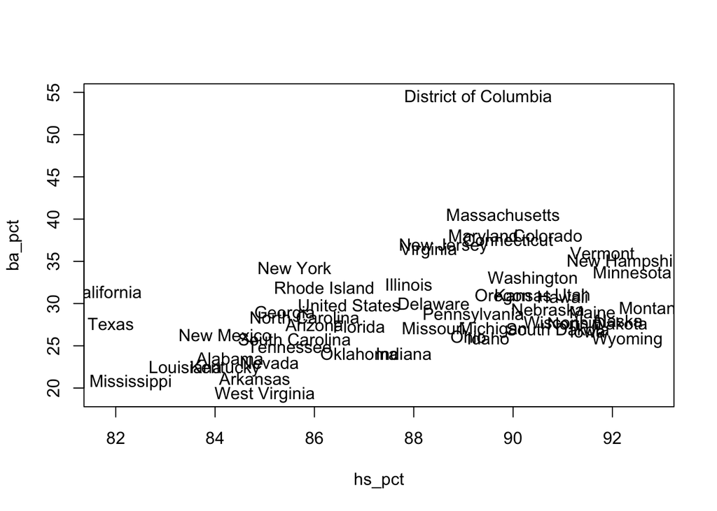

```r
plot(ba_pct ~ hs_pct, data=y, type="n")
text(y$hs_pct, y$ba_pct, y$state )
```

Merge this with our other dataset.

```r
z <- merge(x, y, by="state")
dim(z)
```

```
## [1] 49 14
```

```r
dim(y)
```

```
## [1] 52  4
```

```r
dim(x)
```

```
## [1] 57 11
```

Plot of election outcomes vs. education:

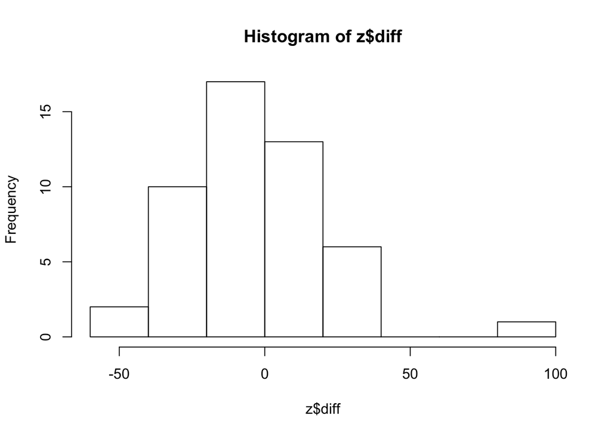

```r
z$diff <- z$clinton_pct - z$trump_pct
hist(z$diff)
```

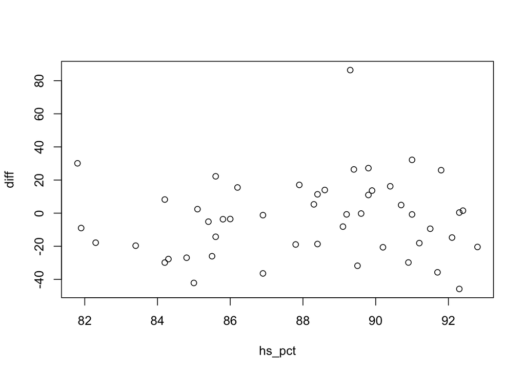

```r
plot(diff ~ hs_pct, data=z)
```

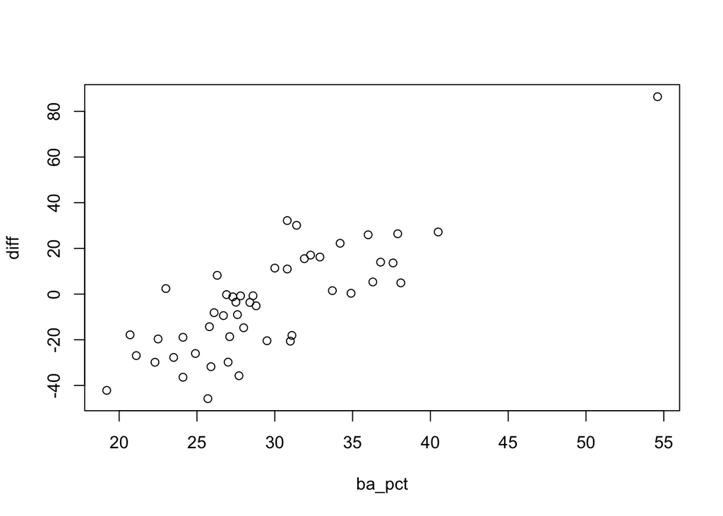

```r
plot(diff ~ ba_pct, data=z)
```

```r
z$state[z$ba_pct > 50]
```

```
## [1] "District of Columbia"
```

```r
z$state[9]
```

```
## [1] "District of Columbia"
```